# Experimental Sociology - Week 04 - In Class

- Show All Code
- Hide All Code
- View Source

Agent-based Models: Basics

Published

2025-04-09

# Task 1: Run the Model Locally

## Did it work?

- Can everyone run the model without errors?
- Is everyone using the latest version of the code (from Monday)?

## Basic Structure

**Show R Code (Summary plot)**

```r
library(DiagrammeR)

grViz("
digraph project_dependencies {
  graph [layout = dot, rankdir = TB]

  node [shape = box, style=filled, fillcolor=lightgrey]

  model      [label = 'functions_model.R\n(contains all models)']
  script     [label = 'script.R']
  simulation [label = 'functions_simulation.R\n(run sim. and replications)']
  sequence   [label = 'functions_sequence.R\n(everything for a sequence)']
  plot       [label = 'functions_plot.R\nfunctions_analysis.R\n(plotting & analysis)']
  data       [label = 'functions_data.R\n(data wrangling)']

  // Top node
  model

  // Connections from script.R
  script -> simulation
  script -> model
  script -> plot

  simulation -> sequence
  simulation -> data
}
")
```

[interactive chart not shown]

Figure 1: Basic File Structure.

## The Files

- The provided files contain a slightly modified version of the code compared to what’s presented online.
- This local version runs significantly faster.
- On a standard PC (50 replications, baseline model):
  - **Online version**: 85 minutes
  - **Without redundancy (removed duplicate happiness checks)**: 16 minutes
  - **With caching of fixed variables**: 14 minutes
  - **Using multiple cores**: 3 minutes

## About Processing Time

The faster your model runs, the better:

- Enables **more experimentation** and interactive exploration.
- Allows for **more replications** and larger-scale models.
- Makes **parameter tuning** and sensitivity analysis feasible.
- **Reduces computational costs** (especially important on shared or cloud resources).

## Redundancy

- In `run_sequence()`, the number of unhappy agents is calculated *twice per step*:

  ```
  # 2) Iterate (without verbose code)
  for (t in seq_len(model$max_t)) {
    unhappy <- get_unhappy_agents(world, model)
    unhappy_series[t] <- length(unhappy) / length(which(V(world)$type != 0))

    segregation_series[t] <- get_data_segregation(world)

    # stop if equilibrium reached
    if (unhappy_series[t] == 0) {
      break
    }

    # otherwise perform one step
    world <- run_step(world, model)
  }
  ```

  - First, to check for equilibrium
  - Then again, during a time step, for find agents that want to relocate
- This results in **duplicated** `get_unhappy_agents()` calls, a costly operation.

## Redundancy - Optimization Strategy

- Move the **unhappiness** and **segregation** calculations into `run_step()`

  ```
    world$data_unhappy     <- length(unhappy) / length(which(V(world)$type != 0))
    world$data_segregation <- get_data_segregation(world)
  ```

- This way:
  - Metrics are computed **once per step**
  - Data is stored **immediately after agent actions**
  - No redundant evaluations

## Redundancy - Optimization Strategy II

- Now, we must rearrange `run_sequence()`

  ```
   # 3) Iterate (without verbose code)
    for (t in seq_len(model$max_t)) {
      # Perform one step (and update metrics inside world)
      world <- run_step(world, model)

      # Store the data from world
      unhappy_series[t]     <- world$data_unhappy
      segregation_series[t] <- world$data_segregation

      # stop if equilibrium reached
      if (unhappy_series[t] == 0) {
        break
      }
    }
  ```

## Storing fixed values

- In our model: The neighborhood is fixed
- Yet `get_unhappy_agents` and `get_data_segregation` both calculate it every time step anew:
  - `nbrs <- adjacent_vertices(world, V(world))`
- Instead: Calc it once in `init_world` and store it in world:
  - `world$nbrs <- adjacent_vertices(world, V(world))`
- And use `world$nbrs` in both functions instead.

## Sequential (One Core)

- Instead of using only one core:

  ```
    results <- vector("list", replications)
    source("functions_sequence.R")

    for (r in seq_len(replications)) {
      model$seed <- master_seed + r
      results[[r]] <- run_sequence(model)
    }
  ```

- We can use multiple cores

## Parallelization (Also for Windows)

```
  # prepare the clusters
  cl <- parallel::makePSOCKcluster(ncores)
  on.exit(parallel::stopCluster(cl), add = TRUE)

  # load the functions needed for
  parallel::clusterEvalQ(cl, {
    source("functions_sequence.R")
  })

  # load all variables into the clusters
  parallel::clusterExport(cl, "model", envir = environment())

  # run the
  results <- parallel::parLapply(
    cl,
    seq_len(replications),
    fun = function(r) {
      model$seed <- master_seed + r
      run_sequence(model)
    }
  )
```

# Task 2: Make the Model More Flexible

## Include a new parameter `nei`

- In our `model`:
  - `nei = 1`
- In `init_world()`:
  - `nei = model$nei`

# Task 3: Understanding the Inverted U-Shaped Curve

## Observation in our model:

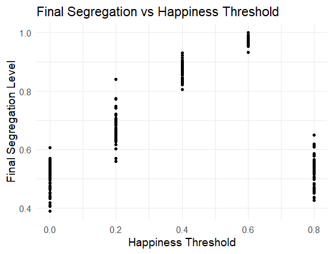

Figure 2

## How to explain?

|  | X |  |
| --- | --- | --- |
| X | X | O |
|  | X |  |

- This configuration represents the **least amount of mixing possible**
- Each agent is surrounded by **75% similar neighbors**,
- Yet this is **below the happiness threshold**
- As a result, **these agent are unhappy**, triggering further movement.

## Copyright

Copyright Sascha Grehl, 2025. All Rights Reserved